# Clipping with gIntersects

This short piece demonstrates how clipping spatial data can be done using the rgeos package in R. A more common method is to use the sp::over function, as detailed in another, larger tutorial [see here](https://github.com/Robinlovelace/Creating-maps-in-R/blob/master/intro-spatial-rl.pdf?raw=true).

The test datasets are contained in the data folder of a repository called Creating-maps-in-R. These, and the rgeos library needed for the function can be loaded with the following commands:

```r
load("data/lnd.RData")
load("data/stations.RData")
library(rgeos)
```

Here, we use `gIntersects`, although we could equally use `gContains`, `gWithin` and other `g...` functions. The power of these commands can be seen by accessing the rgeos help pages, e.g. `?gOverlaps`. `gIntersects` will output information for each point, telling us which polygon it interacts with (i.e. the polygon it is in).

Let's take a look at how the function works on our test data:

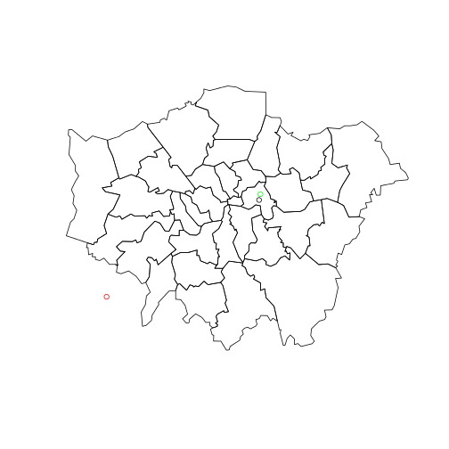

```r
int <- gIntersects(stations, lnd, byid = T)  # find which stations intersect
class(int)  # it's outputed a matrix
dim(int)  # with 33 rows (one for each zone) and 2532 cols (the points)
summary(int[, c(200, 500)])  # not the output of this
plot(lnd)
points(stations[200, ], col = "red")  # note point id 200 is outside the zones
points(stations[500, ], col = "green")  # note point 500 is inside
which(int[, 500] == T)  # this tells us that point 500 intersects with zone 32
points(coordinates(lnd[32, ]), col = "black")  # test the previous statement
```

[output not shown]

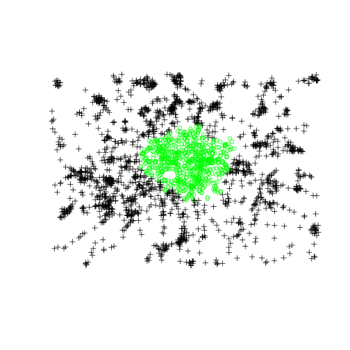

```r
clipped <- apply(int == F, MARGIN = 2, all)
plot(stations[which(clipped), ])  # shows all stations we DO NOT want
stations.cl <- stations[which(!clipped), ]  # use ! to select the invers
points(stations.cl, col = "green")  # check that it's worked
```

```r
stations <- stations.cl
rm(stations.cl)  # tidy up: we're only interested in clipped ones
```

The first line instructs R to look at each column (`MARGIN = 2`, we would use `MARGIN = 1` for row-by-row analysis) and report back whether `all` of the values are false. This creates the inverse selection that we want, hence the use of `!` to invert it. We test that the function works on a new object (often a good idea, to avoid overwriting useful data) with plots and, once content that the clip has worked, save the sample of points to our main `stations` object and remove the now duplicated `stations.cl` object.